# Exchange Curves: Reading a Firm’s Own Costs

Manuel D. Rossetti, PhD P.E.

## Agenda

- One item first: what a chosen operating point implies
- The aggregate curve, and the two quantities that cannot be chosen separately
- Reading a firm’s practice **backwards**
- The **variety index**
- When ordering costs differ across items

## A Different Question

Last session: *given* costs and a constraint, find the quantities.

Today: *given* the quantities a firm is actually using, what does that say about the **costs it is implicitly asserting**?

This is the more useful direction in practice, because most organizations cannot defend their cost parameters but **can** report what they currently do.

## One Item First

A planner decides to order an item **twice a year** and, doing so, carries an average of **$400** of it in stock.

$$\frac{\bar{I}}{\overline{\mathit{OF}}} = \frac{400}{2} = 200 = \frac{k}{\gamma}$$

So the planner’s choice implies $k = 200\gamma$, **whether or not the planner knows it**.

If the firm’s carrying charge is $\gamma = 0.20$ per year, the implied ordering cost is

$$k = \$40$$

## That Number Can Be Checked

Suppose purchasing reports that placing an order genuinely costs **$120**.

Then the ratio **has to be** $120/0.20 = 600$, and the planner is operating at **200**.

The order quantity in use is **too small**, and the item is being ordered far too often for the stated carrying charge.

## Or Read It the Other Way

Take the **practice** as correct instead, and solve for the carrying charge:

$$\gamma = \frac{k}{200} = \frac{120}{200} = 0.60$$

A carrying charge of **60% per year**.

So one of two things is true. Either the item is ordered **too often**, or the firm’s carrying charge is **three times what it says it is**.

Both are defensible. The calculation does not settle which, but it **forces somebody to make one of the two claims**.

## What We Just Did

We obtained a second reading of the ordering cost, from **behavior** rather than from accounting.

Neither reading is authoritative.

Their **disagreement** is the information.

## Now Take Many Items

Define two aggregates over the whole portfolio:

$$\bar{I}^{a} = \sum_{j} c_j\frac{Q_j}{2}
\qquad
N^{a} = \sum_{j}\frac{\lambda_j}{Q_j}$$

The first is **dollars**, and appears on a balance sheet.

The second is **orders per year**, and is what the receiving department feels.

They trade against one another. The question is exactly how.

## Substitute the Economic Quantities

Suppose every item is ordered in its economic quantity, with a common $k$ and a common $\gamma$, so $Q_j = \sqrt{2k\lambda_j/(\gamma c_j)}$.

$$\bar{I}^{a} = \sqrt{\frac{k}{\gamma}}\cdot\frac{1}{\sqrt{2}}\sum_{j}\sqrt{\lambda_j c_j}$$

$$N^{a} = \sqrt{\frac{\gamma}{k}}\cdot\frac{1}{\sqrt{2}}\sum_{j}\sqrt{\lambda_j c_j}$$

Two things follow **at once**.

## The Product, and the Ratio

$$\bar{I}^{a}\cdot N^{a} = \frac{1}{2}\left(\sum_{j}\sqrt{\lambda_j c_j}\right)^{2}$$

$k$ and $\gamma$ have both **cancelled**.

$$\frac{\bar{I}^{a}}{N^{a}} = \frac{k}{\gamma}$$

The **product** is fixed by the item data alone, and defines a single hyperbola: the **exchange curve**.

The **ratio** $k/\gamma$ is a ray from the origin.

Where the ray crosses the curve is where the portfolio operates.

## The Curve

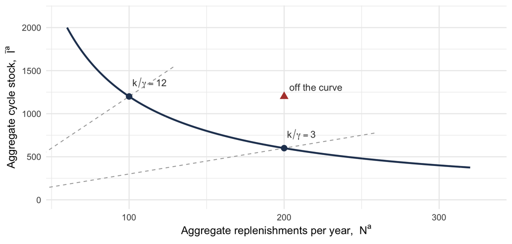

## Reading It Forwards

Follow the curve left to right. Aggregate investment **falls** as the number of replenishments **rises**. That is the trade the product forces.

The curve **flattens** toward the right, so the stock given up for each additional order gets **smaller** as the portfolio orders more often.

Two rays, two operating points: $k/\gamma = 12$ meets the curve at 100 orders and $1,200; $k/\gamma = 3$ meets it at 200 orders and $600.

A firm does **not** choose a point on the curve directly.

It chooses a **cost ratio**, and the ratio chooses the point.

## The Point Above the Curve

The triangle sits at 200 replenishments and $1,200 of stock.

$$200 \times 1200 = 240{,}000 \ne 120{,}000$$

**No set of economic order quantities produces it.** A portfolio found there is ordering in quantities that are not economic.

That portfolio can move **onto** the curve and improve **both measures at once**, with no trade-off to argue about and no new money.

This is the rare case in which an inventory recommendation costs nothing.

## Reading It Backwards

A distributor places **100 orders** a year and carries **$1,200** of cycle stock, on the curve.

$$\frac{\bar{I}^{a}}{N^{a}} = \frac{1200}{100} = 12 = \frac{k}{\gamma}$$

**Case 1, the ordering cost is known.** Estimation puts $k = \$4$:

$$\gamma = \frac{4}{12} = 0.333 \text{ per year}$$

A charge of **33%** is what would make current practice optimal. If the true figure is **20%**, the ratio that should govern is $4/0.20 = 20$, not 12, so the firm is **ordering too often** for the stock it holds.

## Two More Readings

**Case 2, neither cost is known.** The ratio is still informative, because it is what the firm’s **own behavior asserts**.

A manager who cannot produce $k$ or $\gamma$, but who rejects $k/\gamma = 12$ as absurd, **has learned something** about current practice.

**Case 3, the operating point is constrained.** Suppose transportation fixes the portfolio at 200 orders a year. The curve gives $\bar{I}^{a} = \$600$ and a required ratio of 3.

Reaching that ratio cheaply means **reducing $k$**, since $\gamma$ is a property of the cost of capital and is not easily moved.

The curve gives guidance on **changing the environment**, not merely operating within it. It says which cost to attack, and by how much.

## A Consequence Worth Memorizing

Since $\bar{I}^{a} \times N^{a}$ is **constant** along the curve, cutting investment by a factor **scales the workload by its reciprocal**.

Cut inventory investment by **30%**:

$$\frac{1}{0.70} = 1.4286$$

Workload rises **42.86%**.

And that factor is the same **wherever on the curve you start**, because the curve is a rectangular hyperbola and the individual costs cancelled out of the product entirely.

## When Ordering Costs Differ

The simple curve assumed a common $k$. Real portfolios do not have one.

A municipal utility storeroom carries **nine items**. Order handling costs $\kappa = \$55$ per hour, and item $j$ takes $w_j$ hours per order regardless of size, so $k_j = \kappa w_j$.

The curve survives. Only one aggregation is required:

$$\sum_{j}\sqrt{k_j c_j \lambda_j} = 19{,}755.87$$

$$\bar{I}^{a}\cdot\overline{\mathit{OC}}^{a} = \frac{1}{2}(19{,}755.87)^{2} = 1.951\times 10^{8}$$

## Tracing It With the Multiplier

$$\bar{I}^{a} = \frac{\sum_j\sqrt{k_jc_j\lambda_j}}{\sqrt{2\theta}},
\qquad
\overline{\mathit{OC}}^{a} = \sqrt{\frac{\theta}{2}}\sum_j\sqrt{k_jc_j\lambda_j}$$

| $\theta$ | $\bar{I}^{a}$ | $\overline{\mathit{OC}}^{a}$ | Order handling | Product |
| --- | --- | --- | --- | --- |
| 0.05 | $62,474 | $3,124 | 57 hours | $1.951\times 10^{8}$ |
| 0.10 | $44,175 | $4,418 | 80 hours | $1.951\times 10^{8}$ |
| **0.25** | **$27,939** | **$6,985** | **127 hours** | $1.951\times 10^{8}$ |
| 0.50 | $19,756 | $9,878 | 180 hours | $1.951\times 10^{8}$ |
| 1.00 | $13,970 | $13,970 | 254 hours | $1.951\times 10^{8}$ |

The last column is **constant by construction**, and checking it is the arithmetic check for this section.

## Where This Storeroom Sits

The firm’s own carrying charge **is** the multiplier, so $\theta = \gamma = 0.25$ puts it on the third row.

**$27,939** of cycle stock against **$6,985** a year of order handling, which is **127 hours** of a storekeeper’s time.

Since $\bar{I}^{a}/\overline{\mathit{OC}}^{a} = 1/\theta$, the storeroom holds **exactly four dollars of stock for every dollar a year it spends ordering**.

Halving the carrying charge to 0.125 moves it between rows two and three: more stock, less workload, at an exchange rate the curve fixes exactly.

## The Variety Index

$$J^{*} = \frac{\left(\sum_j \sqrt{k_j c_j\lambda_j}\right)^{2}}{K^{w}\lambda^{a}c^{w}}$$

where $\lambda^{a}$ is aggregate demand and $K^{w}$, $c^{w}$ are dollar-usage weighted averages.

It is bounded: $1 \le J^{*} \le J$.

For the storeroom, with denominator $6.870\times 10^{7}$:

$$J^{*} = \frac{(19{,}755.87)^{2}}{6.870\times 10^{7}} = \mathbf{5.68}$$

**Nine items behave in aggregate like fewer than six identical ones.**

## What Drives It

The transformer alone contributes **6,133 of the 19,756** in that sum.

$J^{*}$ reaches its **upper bound $J$** when the items are identical in the relevant product, and falls toward **1** when a single item dominates.

That concentration is the same thing ABC classification measures, arrived at a different way.

And the curve decomposes:

$$\frac{1}{2}J^{*}K^{w}\lambda^{a}c^{w}
= \frac{1}{2}(5.6813)(123.67)(14{,}445)(38.46) = 1.951\times 10^{8}$$

## Four Things Set the Frontier

$$\bar{I}^{a}\cdot\overline{\mathit{OC}}^{a} = \frac{1}{2}J^{*}K^{w}\lambda^{a}c^{w}$$

- $J^{*}$: how **varied** the items are
- $K^{w}$: what an **order** costs
- $\lambda^{a}$: how much is **demanded**
- $c^{w}$: what the goods are **worth**

Nothing else. No policy, no multiplier, no service target.

Which is why the curve can be drawn **before** anything is optimized.

## What We Did Today

**The product is fixed by the item data; the ratio is $k/\gamma$.** A firm chooses a ratio, and the ratio chooses the point.

**A point off the curve is free money.** Both measures improve at once.

**A point on the curve asserts a cost ratio**, which can be compared against the costs the firm claims. A discrepancy says practice is optimal for costs the firm does not have.

**Cutting investment 30% raises workload 42.86%**, from anywhere on the curve.

**The variety index says how alike the items are.** 5.68 for nine items.

## For Next Time

**Read before next session:** *Joint Replenishment*.

We have done the shared **resource**. Next is the shared **setup**, which couples the cost functions themselves and leaves the items unconstrained.

Next session:

- Why a shared order cost is a different problem, not a variant of this one
- **Power-of-two** policies, and why a schedule that nests is one a dock can run
- The 6.07% bound, and where it comes from
- Why **coordination beats cleverness** by a wide margin

The flatness of the EOQ cost curve returns next session, applied to cycle **lengths** instead of order quantities. It does the same work.

⌂ Index